# H2: Coaliciones discursivas

Sección 5.4: detección de comunidades en la red de actores de la Ley 21.735

Este reporte respalda la sección 5.4 del manuscrito. H2 sostiene que en el debate de la Ley 21.735 se identificarán dos polos discursivos principales, vinculados con la justicia de mercado y la justicia política. El polo de preservación empleará argumentos a favor de la propiedad y la capitalización individual, la reciprocidad contributiva, la conciencia de costos y la organización privada y mercantil de la previsión; el polo de transformación se distinguirá por su apoyo a la igualdad o el universalismo y a la solidaridad intergeneracional.

El procedimiento sigue la sección 5 del suplemento metodológico: redes de congruencia y conflicto entre actores normalizadas por coseno, combinadas en una red con signo, y detección de comunidades mediante *signed spin-glass* repetida con distintas semillas. El número de comunidades no se fija. Las etiquetas de preservación y transformación se asignan después, según el repertorio de cada comunidad.

## Seteo de la sesión

**Código**

```r
pacman::p_load(arrow, dplyr, tidyr, purrr, stringr, ggplot2, scales, igraph,
               ggforce, ggrepel, parallel)
source("R/analysis_base.R")
source("R/apa7_word_table.R")

TABLE_DIR <- "output/tables/resultados"
FIGURE_DIR <- "output/figures/resultados"
dir.create(TABLE_DIR, recursive = TRUE, showWarnings = FALSE)
dir.create(FIGURE_DIR, recursive = TRUE, showWarnings = FALSE)
SEED <- 20261021
N_RUNS <- 50L       # semillas de la partición principal
N_RUNS_SENS <- 20L  # semillas de cada análisis de sensibilidad
MAX_SPINS <- 10L    # máximo de comunidades posibles, no su número observado
N_CORES <- max(1L, detectCores() - 1L)
# La caché se invalida si cambian los datos, la base o los parámetros.
knitr::opts_chunk$set(cache.extra = list(tools::md5sum(c(
  "R/analysis_base.R",
  file.path(LUNA_RUN_DIR, c("annotations.parquet", "results.parquet")),
  sprintf("data/proc_data/ley_%s/coding_chunks_long.parquet", names(LAW_LABELS)),
  Sys.glob(file.path(STANCE_ADJUDICATION_DIR, "*", "decisions", "*.json")))),
  SEED, N_RUNS, N_RUNS_SENS, MAX_SPINS))

BLOC_COLORS <- c(Izquierda = "#b03a7a", Centro = "#8c8c8c", Derecha = "#12866f",
                 `No partidista` = "#d9b44a")
COMMUNITY_COLORS <- c("#2f6fa3", "#d1792a", "#6a8f2a", "#7b4f9d", "#a33b3b",
                      "#4d4d4d")
theme_set(theme_minimal(base_size = 11) +
            theme(panel.grid.minor = element_blank()))
```

## Datos

La unidad es el actor con al menos una declaración en intervenciones sustantivas de la Ley 21.735. La afiliación es binaria: para cada concepto se registra si el actor lo apoyó al menos una vez y si lo rechazó al menos una vez. La versión con frecuencias (número de intervenciones con cada postura) se usa como sensibilidad, porque las repeticiones dependen sobre todo de en cuántas sesiones interviene un actor.

**Código**

```r
key <- c("law_number", "document_uri", "utterance_id")
base <- load_analysis_base(LUNA_RUN_DIR)
reform <- base$interventions |> filter(substantive, law_number == "21735")
claims <- base$claims |>
  filter(law_number == "21735") |>
  inner_join(reform |> select(all_of(key), speaker_id, phase), by = key)
actors <- reform |>
  group_by(speaker_id) |>
  summarise(nombre = first(speaker_name), partido = first(party),
            alineacion = first(alignment), genero = first(gender),
            rol = first(role), intervenciones = n(), .groups = "drop") |>
  mutate(bloque = recode(alineacion, izquierda = "Izquierda", centro = "Centro",
                         derecha = "Derecha", nonpartisan = "No partidista",
                         .default = "No partidista"),
         bloque = factor(bloque, levels = names(BLOC_COLORS)))
concept_ids <- sort(unique(claims$concept_id))
# Conceptos de las figuras de redes: actitud se omite por su escasez.
network_concepts <- setdiff(concept_ids, "actitud")
tibble(actores_sustantivos = nrow(actors),
       actores_con_perfil = n_distinct(claims$speaker_id),
       conceptos = length(concept_ids),
       declaraciones = nrow(claims)) |>
  knitr::kable()
```

| actores_sustantivos | actores_con_perfil | conceptos | declaraciones |
| --- | --- | --- | --- |
| 187 | 186 | 14 | 1345 |

## Red con signo

Para cada actor, $B^+_{ac}$ y $B^-_{ac}$ indican si apoyó o rechazó el concepto $c$. Con $n_a = \sqrt{\sum_c [(B^+_{ac})^2 + (B^-_{ac})^2]}$, la congruencia entre dos actores es $G_{ab} = \sum_c (B^+_{ac}B^+_{bc} + B^-_{ac}B^-_{bc}) / (n_a n_b)$, el conflicto es $C_{ab} = \sum_c (B^+_{ac}B^-_{bc} + B^-_{ac}B^+_{bc}) / (n_a n_b)$ y la red con signo es $S = G - C$ (suplemento, sección 5.2).

**Código**

```r
affiliation <- function(cl, ids, binary = TRUE) {
  counts <- cl |>
    count(speaker_id, concept_id, stance) |>
    mutate(n = if (binary) 1 else n)
  build <- function(s) {
    m <- matrix(0, length(ids), length(concept_ids), dimnames = list(ids, concept_ids))
    r <- filter(counts, stance == s)
    m[cbind(match(r$speaker_id, ids), match(r$concept_id, concept_ids))] <- r$n
    m
  }
  list(support = build("support"), oppose = build("oppose"))
}
signed_network <- function(cl, binary = TRUE) {
  ids <- sort(unique(cl$speaker_id))
  x <- affiliation(cl, ids, binary)
  norm <- sqrt(rowSums(x$support^2 + x$oppose^2))
  denom <- outer(norm, norm)
  g <- (tcrossprod(x$support) + tcrossprod(x$oppose)) / denom
  c <- (tcrossprod(x$support, x$oppose) + tcrossprod(x$oppose, x$support)) / denom
  s <- g - c
  diag(g) <- diag(c) <- diag(s) <- 0
  list(ids = ids, G = g, C = c, S = s, affiliation = x)
}
main_net <- signed_network(claims)
stopifnot(isSymmetric(main_net$S), all(abs(main_net$S) <= 1 + 1e-9))
upper <- main_net$S[upper.tri(main_net$S)]
tibble(actores = length(main_net$ids), pares = length(upper),
       positivos = sum(upper > 0), negativos = sum(upper < 0),
       nulos = sum(upper == 0)) |>
  knitr::kable()
```

| actores | pares | positivos | negativos | nulos |
| --- | --- | --- | --- | --- |
| 186 | 17205 | 12368 | 1932 | 2905 |

## Detección de comunidades

`igraph::cluster_spinglass()` con `implementation = "neg"`, que admite pesos negativos, `spins = 10` como máximo de comunidades y los parámetros de resolución por defecto (`gamma = 1`, `gamma.minus = 1`). Se repite con 50 semillas. La partición principal es la de mayor modularidad entre las ejecuciones; la estabilidad se describe con la frecuencia de cada número de comunidades, la concordancia de cada ejecución con la principal y la proporción de ejecuciones en que cada par de actores queda junto.

**Código**

```r
# Ajusta spin-glass con signo; la red debe ser conectada.
run_spinglass <- function(s, seed) {
  graph <- graph_from_adjacency_matrix(s, mode = "undirected", weighted = TRUE,
                                       diag = FALSE)
  set.seed(seed)
  fit <- cluster_spinglass(graph, weights = E(graph)$weight,
                           implementation = "neg", spins = MAX_SPINS)
  list(seed = seed, membership = setNames(as.integer(membership(fit)), rownames(s)),
       modularity = fit$modularity)
}
run_many <- function(s, n_runs, seed0) {
  graph <- graph_from_adjacency_matrix(s, mode = "undirected", weighted = TRUE,
                                       diag = FALSE)
  # Spin-glass requiere una red conectada: si no lo es, se usa el componente
  # mayor y los demás actores quedan sin comunidad (suplemento, sección 5.3).
  parts <- components(graph)
  if (parts$no > 1) {
    keep <- parts$membership == which.max(parts$csize)
    message(sum(!keep), " actores fuera del componente mayor")
    s <- s[keep, keep]
  }
  mclapply(seed0 + seq_len(n_runs), \(seed) run_spinglass(s, seed),
           mc.cores = N_CORES)
}
best_run <- function(runs) runs[[which.max(map_dbl(runs, "modularity"))]]
nmi <- function(a, b) igraph::compare(a, b, method = "nmi")
# Proporción de pares de actores que permanecen juntos o separados en ambas particiones.
pair_agreement <- function(a, b) {
  same_a <- outer(a, a, "==")
  same_b <- outer(b, b, "==")
  mean((same_a == same_b)[upper.tri(same_a)])
}
```

**Código**

```r
runs_main <- run_many(main_net$S, N_RUNS, SEED)
```

**Código**

```r
best <- best_run(runs_main)
# Las comunidades se numeran por su proporción de actores de derecha, de mayor a menor.
right_share <- tapply(actors$bloque[match(names(best$membership), actors$speaker_id)] == "Derecha",
                      best$membership, mean)
relabel <- setNames(seq_along(right_share), names(sort(right_share, decreasing = TRUE)))
membership_main <- setNames(relabel[as.character(best$membership)], names(best$membership))
# Nombres de las coaliciones según su repertorio (sección 5.4): la comunidad con
# más actores de derecha es la de preservación.
COMMUNITY_NAMES <- c("Preservación", "Transformación")
stopifnot(n_distinct(membership_main) == length(COMMUNITY_NAMES))
community_name <- \(k) factor(COMMUNITY_NAMES[k], levels = COMMUNITY_NAMES)
stability <- tibble(
  semilla = map_int(runs_main, "seed"),
  comunidades = map_int(runs_main, \(r) n_distinct(r$membership)),
  modularidad = map_dbl(runs_main, "modularity"),
  nmi_principal = map_dbl(runs_main, \(r) nmi(r$membership, best$membership))
)
stability |>
  count(comunidades, name = "ejecuciones") |>
  knitr::kable(col.names = c("Comunidades", "Ejecuciones"))
```

| Comunidades | Ejecuciones |
| --- | --- |
| 2 | 50 |

**Código**

```r
summary(stability$nmi_principal)
```

```
   Min. 1st Qu.  Median    Mean 3rd Qu.    Max.
 0.9245  0.9569  0.9784  0.9707  1.0000  1.0000
```

**Código**

```r
coassignment <- Reduce(`+`, map(runs_main, \(r) outer(r$membership, r$membership, "=="))) /
  length(runs_main)
diag(coassignment) <- NA
community_stability <- map_dfr(sort(unique(membership_main)), \(k) {
  members <- names(membership_main)[membership_main == k]
  tibble(comunidad = k,
         coasignacion_interna = mean(coassignment[members, members], na.rm = TRUE))
})
```

La partición principal tiene 2 comunidades y modularidad 0,209. 50 de las 50 ejecuciones encuentran el mismo número de comunidades, y la información mutua normalizada mediana entre cada ejecución y la partición principal es 0,98.

## Composición de las comunidades

**Código**

```r
community_actors <- actors |>
  inner_join(tibble(speaker_id = names(membership_main),
                    comunidad = as.integer(membership_main)), by = "speaker_id")
top_parties <- community_actors |>
  count(comunidad, partido, sort = TRUE) |>
  group_by(comunidad) |>
  slice_head(n = 4) |>
  summarise(partidos = paste0(partido, " (", n, ")", collapse = "; "), .groups = "drop")
composition <- community_actors |>
  count(comunidad, bloque) |>
  complete(comunidad, bloque, fill = list(n = 0L)) |>
  group_by(comunidad) |>
  mutate(actores = sum(n), pct = n / actores) |>
  ungroup() |>
  select(-n) |>
  pivot_wider(names_from = bloque, values_from = pct, values_fill = 0) |>
  left_join(community_stability, by = "comunidad") |>
  left_join(top_parties, by = "comunidad")
knitr::kable(composition, digits = 2)
```

| comunidad | actores | Izquierda | Centro | Derecha | No partidista | coasignacion_interna | partidos |
| --- | --- | --- | --- | --- | --- | --- | --- |
| 1 | 85 | 0.08 | 0.05 | 0.86 | 0.01 | 0.98 | Partido Unión Demócrata Independiente (23); Partido Renovación Nacional (22); Partido Republicano De Chile (14); Partido Social Cristiano (8) |
| 2 | 101 | 0.78 | 0.13 | 0.06 | 0.03 | 1.00 | Partido Socialista de Chile (19); Partido Comunista de Chile (16); Partido Por la Democracia (13); Partido Frente Amplio (9) |

**Código**

```r
bloc_nmi <- nmi(as.integer(factor(community_actors$bloque)), community_actors$comunidad)
```

La información mutua normalizada entre las comunidades y el bloque político es 0,45: 1 indicaría que las comunidades reproducen exactamente los bloques, y 0, que son independientes.

## Repertorio de cada comunidad

Para cada comunidad se calcula la proporción de sus actores que apoyan y que rechazan cada concepto, y la diferencia con el resto de los actores. Los conceptos con mayor diferencia son los distintivos de la comunidad.

**Código**

```r
positions <- claims |>
  distinct(speaker_id, concept_id, stance) |>
  inner_join(community_actors |> select(speaker_id, comunidad), by = "speaker_id")
community_sizes <- count(community_actors, comunidad, name = "actores")
repertoire <- positions |>
  count(comunidad, concept_id, stance) |>
  complete(comunidad, concept_id = concept_ids, stance = c("support", "oppose"),
           fill = list(n = 0)) |>
  left_join(community_sizes, by = "comunidad") |>
  mutate(proporcion = n / actores) |>
  group_by(concept_id, stance) |>
  mutate(resto = (sum(n) - n) / (sum(actores) - actores),
         diferencia = proporcion - resto) |>
  ungroup() |>
  mutate(postura = if_else(stance == "support", "Apoyo", "Rechazo"),
         concepto = unname(CONCEPT_SHORT[concept_id]))
write_parquet(repertoire, file.path(TABLE_DIR, "h2_repertorio_comunidades.parquet"))
repertoire |>
  group_by(comunidad) |>
  slice_max(abs(diferencia), n = 8) |>
  transmute(comunidad, concepto, postura, proporcion, resto, diferencia) |>
  knitr::kable(digits = 2)
```

| comunidad | concepto | postura | proporcion | resto | diferencia |
| --- | --- | --- | --- | --- | --- |
| 1 | Propiedad de los fondos | Apoyo | 0.76 | 0.13 | 0.64 |
| 1 | Capitalización individual | Apoyo | 0.55 | 0.01 | 0.54 |
| 1 | Previsión como mercado | Rechazo | 0.16 | 0.67 | -0.51 |
| 1 | Ineficiencia y riesgo estatal | Apoyo | 0.52 | 0.03 | 0.49 |
| 1 | Previsión como mercado | Apoyo | 0.71 | 0.24 | 0.47 |
| 1 | Origen dictatorial | Apoyo | 0.02 | 0.44 | -0.41 |
| 1 | Necesidad material | Apoyo | 0.47 | 0.85 | -0.38 |
| 1 | Capitalización individual | Rechazo | 0.00 | 0.36 | -0.36 |
| 2 | Propiedad de los fondos | Apoyo | 0.13 | 0.76 | -0.64 |
| 2 | Capitalización individual | Apoyo | 0.01 | 0.55 | -0.54 |
| 2 | Previsión como mercado | Rechazo | 0.67 | 0.16 | 0.51 |
| 2 | Ineficiencia y riesgo estatal | Apoyo | 0.03 | 0.52 | -0.49 |
| 2 | Previsión como mercado | Apoyo | 0.24 | 0.71 | -0.47 |
| 2 | Origen dictatorial | Apoyo | 0.44 | 0.02 | 0.41 |
| 2 | Necesidad material | Apoyo | 0.85 | 0.47 | 0.38 |
| 2 | Capitalización individual | Rechazo | 0.36 | 0.00 | 0.36 |

**Código**

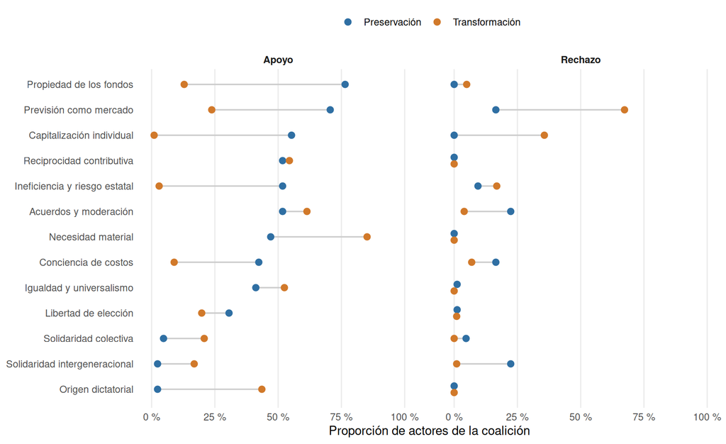

Figura 1: Proporción de actores de cada comunidad que apoya y que rechaza cada concepto, Ley 21.735

```r
concept_order <- repertoire |>
  filter(postura == "Apoyo", comunidad == 1, concept_id != "actitud") |>
  arrange(proporcion) |>
  pull(concepto)
# Actitud se omite de las figuras: tiene dos declaraciones en todo el corpus.
# Cuando ambas comunidades tienen casi la misma proporción, sus puntos se
# separan levemente en vertical para que no se tapen.
plot_repertoire <- repertoire |>
  filter(concept_id != "actitud") |>
  mutate(concepto = factor(concepto, levels = concept_order),
         comunidad = community_name(comunidad)) |>
  group_by(concepto, postura) |>
  mutate(solapa = diff(range(proporcion)) < 0.015,
         y = as.numeric(concepto) +
           if_else(solapa, if_else(comunidad == levels(comunidad)[1], 0.13, -0.13), 0)) |>
  ungroup()
fig_repertoire <- ggplot(plot_repertoire, aes(x = proporcion, y = y, color = comunidad)) +
  geom_line(aes(group = concepto), color = "grey80", linewidth = 0.6) +
  geom_point(size = 2.4) +
  facet_wrap(~ postura) +
  scale_y_continuous(breaks = seq_along(concept_order), labels = concept_order,
                     expand = expansion(add = 0.6)) +
  scale_x_continuous(labels = label_percent(accuracy = 1, suffix = " %"), limits = c(0, 1)) +
  scale_color_manual(values = COMMUNITY_COLORS) +
  labs(x = "Proporción de actores de la coalición", y = NULL, color = NULL) +
  theme(legend.position = "top", panel.grid.major.y = element_blank(),
        strip.text = element_text(face = "bold"), panel.spacing.x = unit(1.5, "lines"))
print(fig_repertoire)
ggsave(file.path(FIGURE_DIR, "figura7_h2_repertorio.png"), fig_repertoire,
       width = 9, height = 5.5, dpi = 300, bg = "white")
```

## Red de actores

La figura dibuja a los actores con una disposición de fuerzas calculada sobre los vínculos positivos de $S$. Para que la red sea legible, se muestran solo los tres vínculos positivos más fuertes de cada actor; la disposición usa todos. El color del nodo indica el bloque político, y el contorno, la comunidad de la partición principal. Las distancias no son una medida estadística.

**Código**

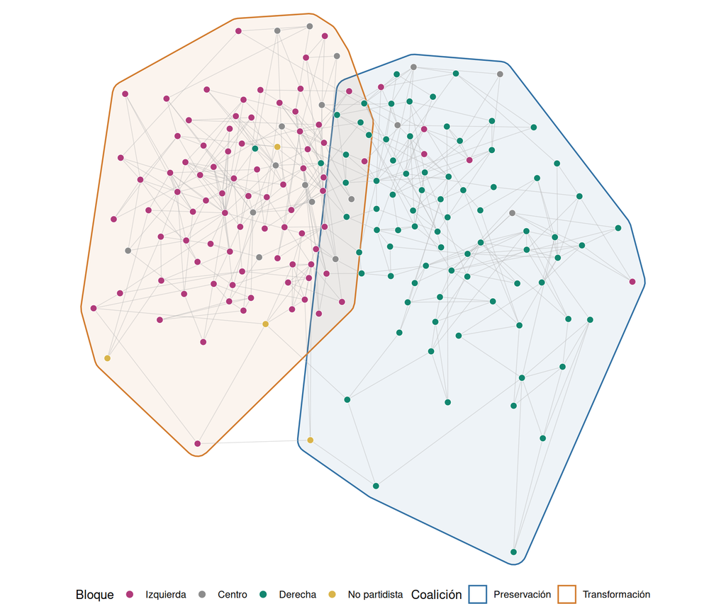

Red de congruencia entre actores y comunidades detectadas, Ley 21.735

```r
positive <- pmax(main_net$S, 0)
graph_pos <- graph_from_adjacency_matrix(positive, mode = "undirected", weighted = TRUE,
                                         diag = FALSE)
set.seed(SEED)
layout <- layout_with_fr(graph_pos, weights = E(graph_pos)$weight, niter = 2000)
nodes <- tibble(speaker_id = main_net$ids, x = layout[, 1], y = layout[, 2]) |>
  left_join(community_actors |> select(speaker_id, bloque, comunidad), by = "speaker_id")
# Los tres vínculos positivos más fuertes de cada actor.
backbone <- map_dfr(seq_along(main_net$ids), \(i) {
  w <- positive[i, ]
  j <- head(order(w, decreasing = TRUE), 3)
  tibble(from = i, to = j[w[j] > 0], weight = w[j[w[j] > 0]])
}) |>
  mutate(a = pmin(from, to), b = pmax(from, to)) |>
  distinct(a, b, .keep_all = TRUE) |>
  mutate(x = layout[a, 1], y = layout[a, 2], xend = layout[b, 1], yend = layout[b, 2])
hulls <- nodes |>
  group_by(comunidad) |>
  slice(chull(x, y)) |>
  ungroup() |>
  mutate(comunidad = community_name(comunidad))
community_levels <- COMMUNITY_NAMES
community_palette <- setNames(COMMUNITY_COLORS[seq_along(community_levels)], community_levels)
fig_actors <- ggplot() +
  geom_shape(data = hulls, aes(x = x, y = y, group = comunidad, fill = comunidad,
                               color = comunidad),
             expand = unit(4, "mm"), radius = unit(4, "mm"), alpha = 0.08,
             linewidth = 0.6) +
  geom_segment(data = backbone, aes(x = x, y = y, xend = xend, yend = yend),
               color = "grey70", alpha = 0.5, linewidth = 0.25) +
  geom_point(data = nodes, aes(x = x, y = y, fill = bloque), shape = 21,
             color = "white", stroke = 0.3, size = 2.6) +
  scale_fill_manual(values = c(BLOC_COLORS, community_palette),
                    breaks = names(BLOC_COLORS), name = "Bloque",
                    guide = guide_legend(override.aes = list(shape = 21, size = 3))) +
  scale_color_manual(values = community_palette, name = "Coalición",
                     guide = guide_legend(override.aes = list(fill = NA))) +
  coord_equal() +
  theme_void() +
  theme(legend.position = "bottom",
        plot.background = element_rect(fill = "white", color = NA))
print(fig_actors)
```

**Código**

```r
ggsave(file.path(FIGURE_DIR, "figura6_h2_red_actores.png"), fig_actors,
       width = 9, height = 7.5, dpi = 300, bg = "white")
```

## Redes de congruencia y de conflicto entre conceptos

En la red de congruencia, dos conceptos se vinculan cuando los mismos actores los apoyan o los rechazan conjuntamente: $W^G_{cd} = \sum_a (B^+_{ac}B^+_{ad} + B^-_{ac}B^-_{ad})$, dividido por las normas de ambos conceptos (suplemento, sección 6.2). En la red de conflicto, dos conceptos se vinculan cuando los mismos actores apoyan uno y rechazan el otro: $W^C_{cd} = \sum_a (B^+_{ac}B^-_{ad} + B^-_{ac}B^+_{ad})$, con el mismo denominador. Ambas redes se dibujan con la misma disposición, calculada sobre la congruencia, y muestran los vínculos con peso de al menos 0,30, la mediana de la red de congruencia. El tamaño del nodo indica cuántos actores usan el concepto, y el color, la comunidad en que el concepto recibe apoyo de una mayor proporción de actores.

**Código**

```r
EDGE_MIN <- 0.30
aff <- main_net$affiliation
concept_norm <- sqrt(colSums(aff$support^2 + aff$oppose^2))
concept_weights <- function(numerator) {
  w <- numerator / outer(concept_norm, concept_norm)
  w[!is.finite(w)] <- 0
  diag(w) <- 0
  w[network_concepts, network_concepts]
}
w_congruence <- concept_weights(crossprod(aff$support) + crossprod(aff$oppose))
w_conflict <- concept_weights(crossprod(aff$support, aff$oppose) +
                                crossprod(aff$oppose, aff$support))
pairs_of <- function(w, red) {
  as_tibble(t(combn(network_concepts, 2)), .name_repair = "minimal") |>
    setNames(c("from", "to")) |>
    mutate(weight = w[cbind(from, to)], red = red)
}
concept_pairs <- bind_rows(pairs_of(w_congruence, "Congruencia"),
                           pairs_of(w_conflict, "Conflicto"))
write_parquet(concept_pairs, file.path(TABLE_DIR, "h2_redes_conceptos.parquet"))
concept_pairs |>
  filter(weight >= EDGE_MIN) |>
  group_by(red) |>
  slice_max(weight, n = 10) |>
  mutate(from = CONCEPT_SHORT[from], to = CONCEPT_SHORT[to]) |>
  knitr::kable(digits = 2)
```

| from | to | weight | red |
| --- | --- | --- | --- |
| Necesidad material | Previsión como mercado | 0.45 | Conflicto |
| Origen dictatorial | Previsión como mercado | 0.43 | Conflicto |
| Capitalización individual | Solidaridad intergeneracional | 0.42 | Conflicto |
| Capitalización individual | Origen dictatorial | 0.37 | Conflicto |
| Acuerdos y moderación | Previsión como mercado | 0.37 | Conflicto |
| Igualdad y universalismo | Previsión como mercado | 0.35 | Conflicto |
| Previsión como mercado | Solidaridad intergeneracional | 0.35 | Conflicto |
| Acuerdos y moderación | Ineficiencia y riesgo estatal | 0.34 | Conflicto |
| Capitalización individual | Necesidad material | 0.34 | Conflicto |
| Previsión como mercado | Reciprocidad contributiva | 0.33 | Conflicto |
| Necesidad material | Reciprocidad contributiva | 0.69 | Congruencia |
| Igualdad y universalismo | Reciprocidad contributiva | 0.63 | Congruencia |
| Igualdad y universalismo | Necesidad material | 0.62 | Congruencia |
| Acuerdos y moderación | Necesidad material | 0.60 | Congruencia |
| Acuerdos y moderación | Igualdad y universalismo | 0.58 | Congruencia |
| Capitalización individual | Previsión como mercado | 0.54 | Congruencia |
| Ineficiencia y riesgo estatal | Propiedad de los fondos | 0.52 | Congruencia |
| Acuerdos y moderación | Reciprocidad contributiva | 0.51 | Congruencia |
| Origen dictatorial | Necesidad material | 0.51 | Congruencia |
| Capitalización individual | Propiedad de los fondos | 0.48 | Congruencia |

Redes de congruencia y de conflicto entre conceptos, Ley 21.735

**Código**

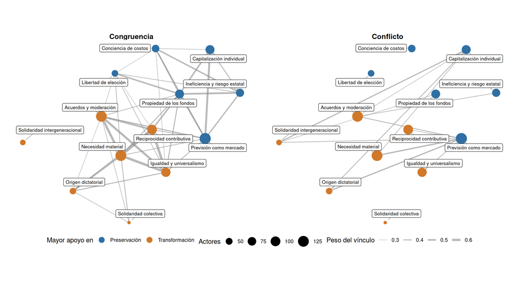

Redes de congruencia y de conflicto entre conceptos, Ley 21.735

```r
graph_concepts <- graph_from_data_frame(filter(concept_pairs, red == "Congruencia", weight > 0),
                                        directed = FALSE,
                                        vertices = tibble(name = network_concepts))
set.seed(SEED)
concept_layout <- layout_with_fr(graph_concepts, weights = E(graph_concepts)$weight,
                                 niter = 3000)
dominant <- repertoire |>
  filter(postura == "Apoyo") |>
  group_by(concept_id) |>
  slice_max(proporcion, n = 1, with_ties = FALSE) |>
  ungroup() |>
  select(concept_id, comunidad)
concept_nodes <- tibble(concept_id = network_concepts, x = concept_layout[, 1],
                        y = concept_layout[, 2],
                        actores = colSums((aff$support + aff$oppose) > 0)[network_concepts]) |>
  left_join(dominant, by = "concept_id") |>
  mutate(concepto = unname(CONCEPT_SHORT[concept_id]),
         comunidad = community_name(comunidad)) |>
  tidyr::crossing(red = c("Congruencia", "Conflicto"))
concept_edges <- concept_pairs |>
  filter(weight >= EDGE_MIN) |>
  mutate(x = concept_layout[match(from, network_concepts), 1],
         y = concept_layout[match(from, network_concepts), 2],
         xend = concept_layout[match(to, network_concepts), 1],
         yend = concept_layout[match(to, network_concepts), 2])
fig_concepts <- ggplot() +
  geom_segment(data = concept_edges,
               aes(x = x, y = y, xend = xend, yend = yend, linewidth = weight),
               color = "grey55", alpha = 0.6) +
  geom_point(data = concept_nodes, aes(x = x, y = y, size = actores, color = comunidad)) +
  geom_label_repel(data = concept_nodes, aes(x = x, y = y, label = concepto),
                   size = 2.8, seed = SEED, box.padding = 0.5, point.padding = 0.4,
                   label.size = 0.15, min.segment.length = 0, segment.color = "grey55",
                   segment.size = 0.3, max.overlaps = Inf) +
  facet_wrap(~ factor(red, levels = c("Congruencia", "Conflicto"))) +
  scale_linewidth(range = c(0.3, 2.2), limits = c(EDGE_MIN, NA), name = "Peso del vínculo") +
  scale_size(range = c(2, 8), name = "Actores") +
  scale_color_manual(values = setNames(COMMUNITY_COLORS[seq_len(nlevels(concept_nodes$comunidad))],
                                       levels(concept_nodes$comunidad)),
                     name = "Mayor apoyo en") +
  coord_equal(clip = "off") +
  theme_void() +
  guides(linewidth = guide_legend(nrow = 1), size = guide_legend(nrow = 1),
         color = guide_legend(nrow = 1, override.aes = list(size = 4))) +
  theme(legend.position = "bottom", legend.box = "horizontal",
        strip.text = element_text(face = "bold", size = 12),
        panel.spacing = unit(2, "lines"),
        plot.background = element_rect(fill = "white", color = NA),
        plot.margin = margin(10, 20, 10, 20))
print(fig_concepts)
```

**Código**

```r
ggsave(file.path(FIGURE_DIR, "figura8_h2_red_conceptos.png"), fig_concepts,
       width = 12, height = 6.5, dpi = 300, bg = "white")
```

## Análisis de sensibilidad

**Código**

```r
variants <- list(
  `Sin acuerdos y moderación` = signed_network(filter(claims, concept_id != "acuerdos_moderacion")),
  `Frecuencias` = signed_network(claims, binary = FALSE)
)
for (ph in levels(droplevels(claims$phase))) {
  variants[[paste("Fase:", ph)]] <- signed_network(filter(claims, phase == ph))
}
runs_sens <- imap(variants, \(net, name) run_many(net$S, N_RUNS_SENS, SEED + 1000L))
```

```
1 actores fuera del componente mayor
```

**Código**

```r
sensitivity <- imap_dfr(runs_sens, \(runs, name) {
  m <- best_run(runs)$membership
  common <- intersect(names(m), names(membership_main))
  tibble(variante = name, actores = length(m), comunes = length(common),
         comunidades = n_distinct(m),
         nmi = nmi(m[common], membership_main[common]),
         pares_concordantes = pair_agreement(m[common], membership_main[common]))
})
write_parquet(sensitivity, file.path(TABLE_DIR, "h2_sensibilidad.parquet"))
knitr::kable(sensitivity, digits = 2)
```

| variante | actores | comunes | comunidades | nmi | pares_concordantes |
| --- | --- | --- | --- | --- | --- |
| Sin acuerdos y moderación | 185 | 185 | 3 | 0.80 | 0.93 |
| Frecuencias | 186 | 186 | 3 | 0.82 | 0.95 |
| Fase: Cámara 2024 | 103 | 103 | 2 | 0.77 | 0.92 |
| Fase: Senado 2025 | 44 | 44 | 2 | 0.49 | 0.79 |
| Fase: Cámara 2025 | 131 | 131 | 3 | 0.35 | 0.66 |

## Tabla para el manuscrito

**Código**

```r
pct <- \(x) paste0(round(100 * x), " %")
tabla_h2 <- composition |>
  transmute(Coalición = COMMUNITY_NAMES[comunidad],
            Actores = as.character(actores),
            Izquierda = pct(Izquierda), Centro = pct(Centro), Derecha = pct(Derecha),
            `No partidista` = pct(`No partidista`),
            `Coasignación` = formatC(coasignacion_interna, format = "f", digits = 2,
                                     decimal.mark = ","),
            `Partidos principales` = partidos)
export_apa7_word_table(
  tabla_h2, file.path(TABLE_DIR, "anexo_h2_comunidades.docx"),
  "Composición y estabilidad de las comunidades detectadas, Ley N.º 21.735",
  note = paste0(
    "Partición de mayor modularidad entre ", N_RUNS, " ejecuciones de signed spin-glass. ",
    "Coasignación: proporción media de ejecuciones en que dos actores de la comunidad ",
    "quedan juntos. Entre paréntesis, número de actores de cada partido."),
  table_number = 6L, landscape = TRUE, body_font_size = 11)
write_parquet(community_actors, file.path(TABLE_DIR, "h2_comunidades_actores.parquet"))
```